# Statistical Inference

Jolien Cremers (adapted from Gerko Vink)

Statistical Programming with R

# Statistical Inference

## This Lecture:

- Plotting distributions
- Comparing two groups
- Checking assuptions
- Non-parametric tests

## I use the following package in this lecture

```r
library(magrittr) #for pipes
library(MASS)     #for the bacteria data
library(Ecdat)    #for the Benefits data
```

# Plotting distributions

## Plotting curves

Base R function `curve()` to plot the pdf and cdf of a normal distribution:

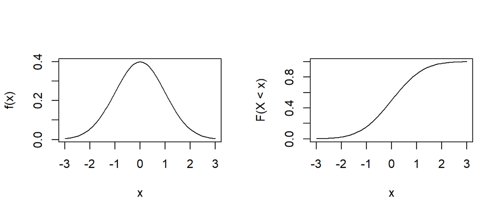

```r
par(mfrow=c(1,2), bg=NA)
curve(dnorm(x,0,1),xlim=c(-3,3),ylab="f(x)",main='')
curve(pnorm(x,0,1),xlim=c(-3,3),ylab="F(X < x)",main='')
```

or exponential distribution:

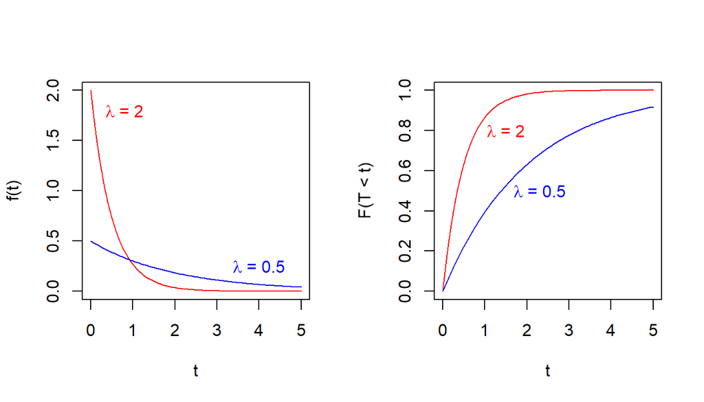

## Sampling from distributions:

In R we can use:

- `rnorm()` to obtain samples from a normal distribution
- `dnorm()` to sample from a normal density function
- `pnorm()` to sample from a normal distribution function
- `qnorm()` to sample from a normal quantile function

This works for other distributions as well, e.g. `rexp()`, `dexp()`, `pexp()` and `qexp()`.

## Setting a seed

```r
set.seed (101)
rnorm(5, 2, 5)
```

```
## [1]  0.3698175  4.7623093 -1.3747192  3.0717973  3.5538461
```

```r
rnorm(5, 2, 5)
```

```
## [1] 7.8698314 5.0939493 1.4363284 6.5851414 0.8837032
```

```r
set.seed(101)
rnorm(5, 2, 5)
```

```
## [1]  0.3698175  4.7623093 -1.3747192  3.0717973  3.5538461
```

## Histograms

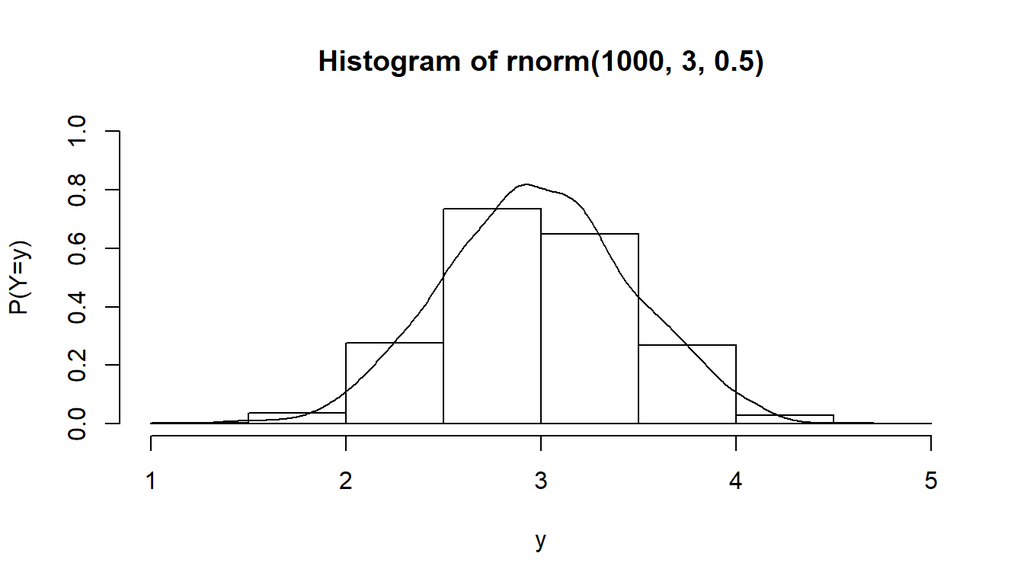

## Code for previous plot

```r
hist(rnorm(1000, 3, 0.5),
     ylab = "P(Y=y)", xlab = "y",
     ylim = c(0,1), prob = TRUE)
lines(density(rnorm(1000, 3, 0.5)))
```

## Barplots

Barplots for a poisson distribution:

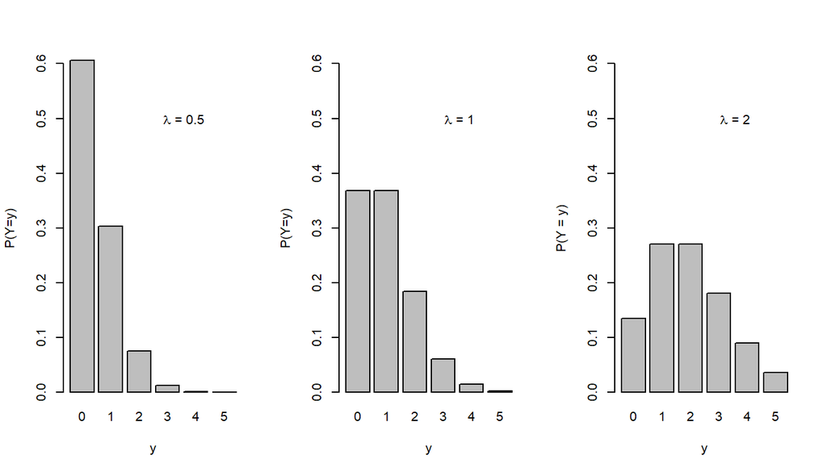

## Code for the previous plot

```r
par(mfrow = c(1, 3), bg = NA)
y <- factor(0:5)
x <- 0:5
barplot(dpois(x, .5), ylim = c(0, .6), names.arg = y,
        ylab = "P(Y=y)", xlab = "y")
text(5, .5, expression(paste(lambda, " = 0.5")))
barplot(dpois(x, 1),
        ylim = c(0, .6),
        names.arg = y,
        ylab = "P(Y=y)",
        xlab = "y")
text(5, .5, expression(paste(lambda, " = 1")))
barplot(dpois(x, 2), ylim = c(0, .6), names.arg = y,
        ylab = "P(Y = y)",xlab="y")
text(5,.5,expression(paste(lambda," = 2")))
```

# Comparing two groups

## Discrete variables

```r
bacteria %>% head(n=8)
```

```
##   y ap hilo week  ID     trt
## 1 y  p   hi    0 X01 placebo
## 2 y  p   hi    2 X01 placebo
## 3 y  p   hi    4 X01 placebo
## 4 y  p   hi   11 X01 placebo
## 5 y  a   hi    0 X02   drug+
## 6 y  a   hi    2 X02   drug+
## 7 n  a   hi    6 X02   drug+
## 8 y  a   hi   11 X02   drug+
```

## Discrete variables

Column `y`:

- `n`: Disease absent.
- `y`: Disease present.

Column `ap`:

- `a`: Active medicine.
- `p`: Placebo.

## Chi-square test

```r
x2.table <- bacteria %$% table(ap, y) #do not need data argument
x2.table
```

```
##    y
## ap   n  y
##   a 31 93
##   p 12 84
```

```r
prop.table(table(bacteria$ap, bacteria$y), margin = 1)
```

```
##
##         n     y
##   a 0.250 0.750
##   p 0.125 0.875
```

## Performing a chi-square test

```r
bacteria %$% chisq.test(ap, y)
```

```
##
##  Pearson's Chi-squared test with Yates' continuity correction
##
## data:  ap and y
## X-squared = 4.6109, df = 1, p-value = 0.03177
```

## Or, equivalently:

```r
bacteria %$% table(ap, y) %>% chisq.test
```

```
##
##  Pearson's Chi-squared test with Yates' continuity correction
##
## data:  .
## X-squared = 4.6109, df = 1, p-value = 0.03177
```

## Expected cell counts

```r
bacteria %$% chisq.test(ap, y)$expected
```

```
##    y
## ap         n        y
##   a 24.23636 99.76364
##   p 18.76364 77.23636
```

## Visualizing this

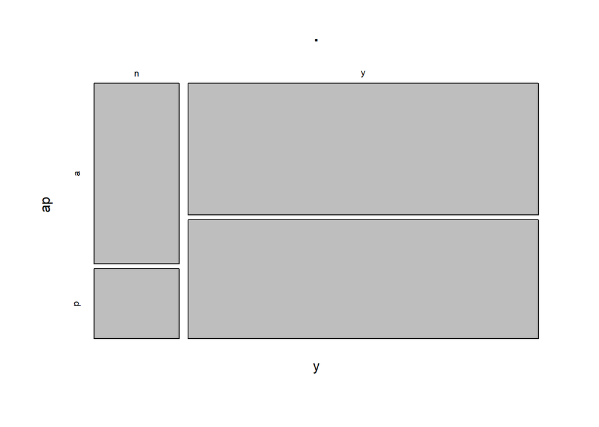

```r
bacteria %$% table(y, ap) %>% plot
```

## Visualizing this

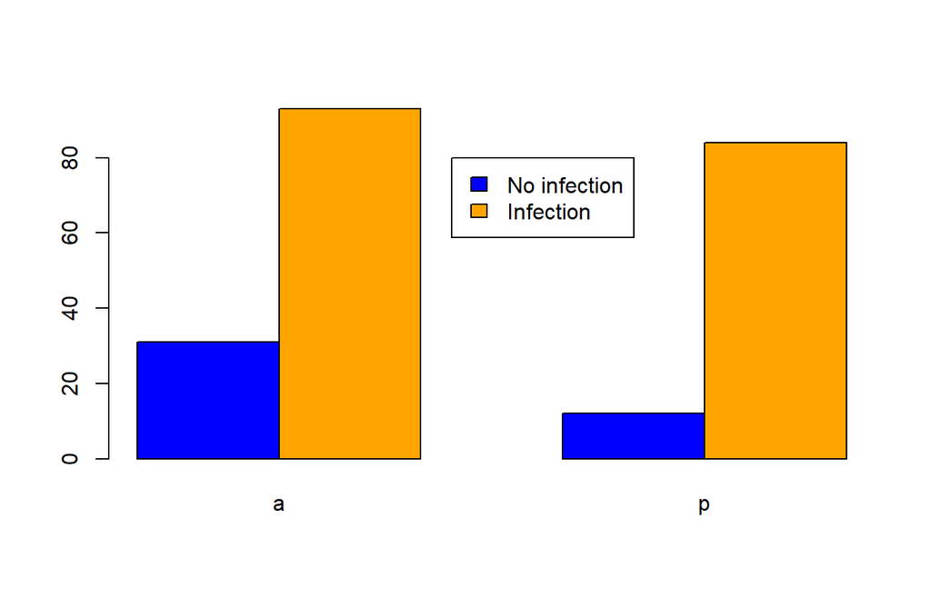

```r
barplot(table(bacteria$y, bacteria$ap),
        beside = TRUE,
        legend = c("No infection", "Infection"),
        col = c("blue", "orange"),
        args.legend = list(x=4.5, y=80))
```

## Continuous variables

```r
head(Benefits, n = 5)
```

```
##   stateur statemb state age tenure    joblost nwhite school12    sex
## 1     4.5     167    42  49     21      other     no       no   male
## 2    10.5     251    55  26      2 slack_work     no       no   male
## 3     7.2     260    21  40     19      other     no      yes female
## 4     5.8     245    56  51     17 slack_work    yes       no female
## 5     6.5     125    58  33      1 slack_work     no      yes   male
##   bluecol smsa married dkids dykids yrdispl        rr head  ui
## 1     yes  yes      no    no     no       7 0.2906310  yes yes
## 2     yes  yes      no   yes    yes      10 0.5202020  yes  no
## 3     yes  yes     yes    no     no      10 0.4324895  yes yes
## 4     yes  yes     yes    no     no      10 0.5000000   no yes
## 5     yes  yes     yes   yes    yes       4 0.3906250  yes  no
```

Unemployment of blue collar workers:

Column `stateur`:

- state unemployment rate (in %)

Column `sex`:

- `male`
- `female`

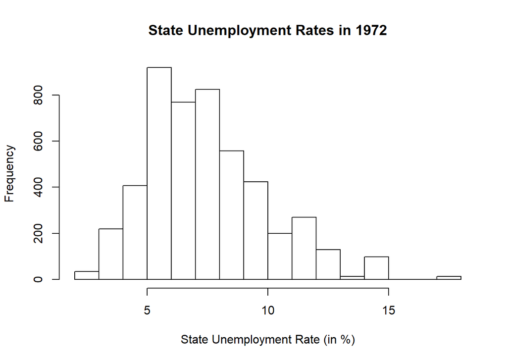

```r
hist(Benefits$stateur, xlim=c(2,18),
     main = "State Unemployment Rates in 1972",
     xlab = "State Unemployment Rate (in %)")
```

## Two-sided t-test

```r
Benefits %$% t.test(stateur, mu = 5, alternative = "two.sided")
```

```
##
##  One Sample t-test
##
## data:  stateur
## t = 70.127, df = 4876, p-value < 2.2e-16
## alternative hypothesis: true mean is not equal to 5
## 95 percent confidence interval:
##  7.440834 7.581229
## sample estimates:
## mean of x
##  7.511031
```

## One-sided t-test

```r
Benefits %$% t.test(stateur, mu = 5, alternative = "greater")
```

```
##
##  One Sample t-test
##
## data:  stateur
## t = 70.127, df = 4876, p-value < 2.2e-16
## alternative hypothesis: true mean is greater than 5
## 95 percent confidence interval:
##  7.452123      Inf
## sample estimates:
## mean of x
##  7.511031
```

## Two-sample t-test

```r
Benefits %$% t.test(stateur~sex)
```

```
##
##  Welch Two Sample t-test
##
## data:  stateur by sex
## t = -2.8681, df = 2023.4, p-value = 0.004172
## alternative hypothesis: true difference in means is not equal to 0
## 95 percent confidence interval:
##  -0.39311976 -0.07383349
## sample estimates:
## mean in group female   mean in group male
##             7.332609             7.566085
```

## ANOVA

```r
fit <- Benefits %$% aov(stateur~sex)
summary(fit)
```

```
##               Df Sum Sq Mean Sq F value  Pr(>F)
## sex            1     48   47.91   7.672 0.00563 **
## Residuals   4875  30441    6.24
## ---
## Signif. codes:  0 '***' 0.001 '**' 0.01 '*' 0.05 '.' 0.1 ' ' 1
```

# Some Assumptions

## Small expected cell frequencies

With small expected cell frequencies (roughly if any are below 5), we should use Fishers exact test.

```r
short <- bacteria %>%
  subset(week <= 2) %$%
  table(y, ap)
short
```

```
##    ap
## y    a  p
##   n  6  3
##   y 47 38
```

## Fisher’s exact test

```r
short %>% chisq.test
```

```
##
##  Pearson's Chi-squared test with Yates' continuity correction
##
## data:  .
## X-squared = 0.090475, df = 1, p-value = 0.7636
```

## Fisher’s exact test

```r
#fisher.test(table(short$y, short$ap))
short %>%
  fisher.test
```

```
##
##  Fisher's Exact Test for Count Data
##
## data:  .
## p-value = 0.7268
## alternative hypothesis: true odds ratio is not equal to 1
## 95 percent confidence interval:
##   0.3182193 10.5996850
## sample estimates:
## odds ratio
##   1.609049
```

## Assumptions in ANOVA

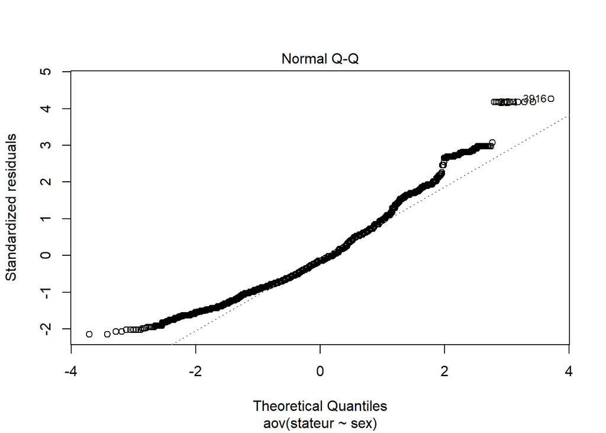

```r
fit <- Benefits %$% aov(stateur~sex)
plot(fit, 2)
```

# Non-parametric testing

## Mann-Whitney / Wilcoxon rank-sum test

Check whether two population distributions (independent samples) are identical without assuming normality.

```r
Benefits %$% wilcox.test(stateur~sex, paired = FALSE)
```

```
##
##  Wilcoxon rank sum test with continuity correction
##
## data:  stateur by sex
## W = 2038781, p-value = 0.0125
## alternative hypothesis: true location shift is not equal to 0
```

set `paired = TRUE` for Wilcoxon signed-rank test for dependent samples.

## Kruskal-wallis test

Check whether a collection of population distributions (independent samples) are identical without assuming normality.

```r
Benefits %$% kruskal.test(stateur~sex)
```

```
##
##  Kruskal-Wallis rank sum test
##
## data:  stateur by sex
## Kruskal-Wallis chi-squared = 6.239, df = 1, p-value = 0.0125
```

## Some other non-parametric tests in `R`

- `friedman.test`: Friedman rank sum test
- `Rfit` package for nonparametric regression
- `cor(x, y, method = "kendall")` for Kendalls tau-b correlation
- `cor(x, y, method = "spearman")` for Spearman correlation
- `survival` package for semi- and nonparametric methods (Kaplan-Meier/Cox regression) in survival analysis